# Power & sample-size for the 2 × 2 Social Exclusion experiment

- Show All Code
- Hide All Code
- View Source

Author

Ceren

Published

July 13, 2026

## Overview

This document estimates the sample size for the new design. I report two anchors — our own pilot and Chen & Li(2009)’s identity effects — so we can compare both before fixing N for the preregistration.

Two complementary approaches:

- **Analytical power** via `pwr::pwr.f2.test()`. Closed-form; returns one required N per assumed effect size.
- **Monte Carlo simulation.** A full power curve across sample sizes and effect sizes, so the trade-off is visible rather than a single point.

Thresholds throughout: **α = 0.05, power = 0.90**.

## The design being powered

Between-subjects 2 × 2 factorial:

| Factor | Level 1 | Level 2 |
| --- | --- | --- |
| **Identity** | no identity | identity (Klee / Kandinsky minimal group) |
| **Exclusion** | random (computer) | spectator (independent participant) |

The four cells correspond to four of the five treatments in the oTree code (`T1`, `T2`, `T4`, `T5`). `T3` (identity × no exclusion) remains in the design as a manipulation check but is not part of the 2 × 2 factorial powered here.

**Primary test:** the Identity × Exclusion **interaction** on dictator-game giving. Outcome: EMU allocated to the recipient.

## What the pilot tells us

```r
pilot_treatment <- read_csv2(file.path(PILOT_DIR, "treatment_pilot.csv"))
pilot_control   <- read_csv2(file.path(PILOT_DIR, "control_pilot.csv"))

pilot <- bind_rows(pilot_treatment, pilot_control) |>
  mutate(
    dg   = if_else(role_dg == 1, group_sent, send_proxy),
    fair = case_when(
      payoff_beneficiary == 10 ~ "fair",
      payoff_beneficiary  > 10 ~ "excluder",
      payoff_beneficiary  < 10 ~ "excluded"
    )
  ) |>
  filter(!is.na(dg))

cat("Usable pilot N:", nrow(pilot),
    "  (treatment:", sum(pilot$condition == "treatment"),
    "control:",  sum(pilot$condition == "control"), ")\n")
```

```
Usable pilot N: 381   (treatment: 199 control: 182 )
```

### Marginal means by condition

```r
pilot |>
  group_by(condition) |>
  summarise(n = n(),
            mean = round(mean(dg), 3),
            sd   = round(sd(dg), 3)) |>
  knitr::kable()
```

| condition | n | mean | sd |
| --- | --- | --- | --- |
| control | 182 | 4.126 | 2.068 |
| treatment | 199 | 4.508 | 1.507 |

### Cell means (condition × fair status)

```r
pilot |>
  group_by(condition, fair) |>
  summarise(n = n(),
            mean = round(mean(dg), 3),
            sd   = round(sd(dg), 3),
            .groups = "drop") |>
  knitr::kable()
```

| condition | fair | n | mean | sd |
| --- | --- | --- | --- | --- |
| control | excluded | 52 | 4.000 | 2.722 |
| control | excluder | 49 | 4.449 | 1.308 |
| control | fair | 81 | 4.012 | 1.959 |
| treatment | excluded | 57 | 4.088 | 1.939 |
| treatment | excluder | 55 | 4.600 | 1.617 |
| treatment | fair | 87 | 4.724 | 0.985 |

### Effect sizes we can extract from the pilot

```r
d_condition <- with(pilot, {
  tv <- dg[condition == "treatment"]
  cv <- dg[condition == "control"]
  n1 <- length(tv); n2 <- length(cv)
  m1 <- mean(tv);   m2 <- mean(cv)
  s1 <- sd(tv);     s2 <- sd(cv)
  ps <- sqrt(((n1 - 1) * s1^2 + (n2 - 1) * s2^2) / (n1 + n2 - 2))
  (m1 - m2) / ps
})

aov_cond   <- aov(dg ~ condition, data = pilot)
ss         <- summary(aov_cond)[[1]][, "Sum Sq"]
eta2_cond  <- ss[1] / sum(ss)
f_cond     <- sqrt(eta2_cond / (1 - eta2_cond))
pilot_sd   <- sd(pilot$dg)

tibble(
  metric = c("Cohen's d (treatment vs control)",
             "eta^2 (condition)",
             "Cohen's f (condition)",
             "Overall SD of dg (noise anchor for the sims)"),
  value  = round(c(d_condition, eta2_cond, f_cond, pilot_sd), 4)
) |>
  knitr::kable()
```

| metric | value |
| --- | --- |
| Cohen’s d (treatment vs control) | 0.2121 |
| eta^2 (condition) | 0.0112 |
| Cohen’s f (condition) | 0.1062 |
| Overall SD of dg (noise anchor for the sims) | 1.8047 |

The pilot’s condition effect is **small** on Cohen’s benchmarks (`d ≈ 0.21`, `f ≈ 0.11`, with `f = 0.10` the small threshold). This is the effect size that drives the pilot-anchored sample sizes reported below.

## Analytical power under the pilot anchor

The primary test is the Identity × Exclusion interaction in a 2 × 2 between-subjects ANOVA, so:

- Numerator df: `u = (a − 1)(b − 1) = 1`
- Denominator df: `v = N − a·b = N − 4`
- Total N: `v + 4`, cell n: `N / 4`

The table below sweeps four effect-size scenarios so the sample-size can be read directly against the assumed effect size.

```r
power_2x2_interaction <- function(f, alpha = 0.05, power = 0.90) {
  res <- pwr.f2.test(u = 1, f2 = f^2,
                     sig.level = alpha, power = power)
  N_total <- ceiling(res$v + 4)
  data.frame(
    f          = f,
    f_squared  = round(f^2, 5),
    v_denom_df = ceiling(res$v),
    N_total    = N_total,
    n_per_cell = ceiling(N_total / 4)
  )
}

scenarios <- data.frame(
  scenario = c("Pilot-derived (single-factor)",
               "Small  (Cohen benchmark)",
               "Small-to-medium",
               "Medium (Cohen benchmark)"),
  f        = c(round(f_cond, 3), 0.10, 0.15, 0.25)
)

primary_results <- do.call(rbind, lapply(seq_len(nrow(scenarios)), function(i) {
  cbind(scenario = scenarios$scenario[i],
        power_2x2_interaction(scenarios$f[i], alpha, power))
}))

knitr::kable(primary_results,
             caption = "Sample sizes for the 2 × 2 interaction under the pilot anchor (α = 0.05, power = 0.90)")
```

Sample sizes for the 2 × 2 interaction under the pilot anchor (α = 0.05, power = 0.90)

| scenario | f | f_squared | v_denom_df | N_total | n_per_cell |
| --- | --- | --- | --- | --- | --- |
| Pilot-derived (single-factor) | 0.106 | 0.01124 | 936 | 940 | 235 |
| Small (Cohen benchmark) | 0.100 | 0.01000 | 1051 | 1055 | 264 |
| Small-to-medium | 0.150 | 0.02250 | 467 | 471 | 118 |
| Medium (Cohen benchmark) | 0.250 | 0.06250 | 169 | 173 | 44 |

At the pilot’s effect size (`f ≈ 0.11`), ~235 per cell are required for 90 % power on the interaction. At `f = 0.15` (small-to-medium) this drops to ~120 per cell. At `f = 0.25` (medium) it drops further to ~44 per cell.

## Secondary tests

Two supporting analyses are included.

### 5-treatment omnibus ANOVA

```r
five_treatment <- data.frame(
  scenario = c("Pilot-derived", "Small", "Small-to-medium", "Medium"),
  f        = c(round(f_cond, 3), 0.10, 0.15, 0.25)
)
five_treatment$n_per_cell <- sapply(five_treatment$f, function(f) {
  ceiling(pwr.anova.test(k = 5, f = f,
                         sig.level = alpha, power = power)$n)
})
five_treatment$N_total <- five_treatment$n_per_cell * 5
knitr::kable(five_treatment,
             caption = "Sample sizes for the omnibus 5-treatment ANOVA")
```

Sample sizes for the omnibus 5-treatment ANOVA

| scenario | f | n_per_cell | N_total |
| --- | --- | --- | --- |
| Pilot-derived | 0.106 | 276 | 1380 |
| Small | 0.100 | 310 | 1550 |
| Small-to-medium | 0.150 | 138 | 690 |
| Medium | 0.250 | 51 | 255 |

### Within-subjects paired contrasts

Under the strategy method each participant supplies paired observations (Round 2: in-group vs out-group; Round 3: easy vs hard recipient). These paired tests require far fewer participants than the between-subjects interaction, so they will be well-powered as a by-product of powering the interaction. The between-subjects interaction is the binding constraint.

```r
paired_scenarios <- data.frame(
  scenario = c("Small  (d = 0.20)", "Small-to-medium (d = 0.30)",
               "Medium (d = 0.50)"),
  d        = c(0.20, 0.30, 0.50)
)
paired_scenarios$n_needed <- sapply(paired_scenarios$d, function(d) {
  ceiling(pwr.t.test(d = d, sig.level = alpha, power = power,
                     type = "paired", alternative = "two.sided")$n)
})
knitr::kable(paired_scenarios,
             caption = "Sample sizes for within-subjects paired contrasts")
```

Sample sizes for within-subjects paired contrasts

| scenario | d | n_needed |
| --- | --- | --- |
| Small (d = 0.20) | 0.2 | 265 |
| Small-to-medium (d = 0.30) | 0.3 | 119 |
| Medium (d = 0.50) | 0.5 | 44 |

## Simulation-based power

For each candidate cell size and each assumed effect size, the routine below simulates `n_sims` replicate datasets with a crossover cell-mean pattern (so Cohen’s f of the pure interaction equals the target exactly), fits `aov(y ~ A * B)`, and counts the proportion of simulations in which the interaction reaches `p < α`. Noise is Normal with SD anchored to the pilot’s DG SD, so residual variance is realistic for the outcome that will actually be observed.

```r
simulate_power_2x2 <- function(n_per_cell,
                               f,
                               sd     = pilot_sd,
                               n_sims = 500,
                               alpha  = 0.05) {
  delta <- f * sd
  cell_means <- c(-delta, +delta, +delta, -delta)  # A1B1, A1B2, A2B1, A2B2
  A  <- factor(rep(c("A1", "A1", "A2", "A2"), each = n_per_cell))
  B  <- factor(rep(c("B1", "B2", "B1", "B2"), each = n_per_cell))
  mu <- rep(cell_means, each = n_per_cell)
  n_sig <- 0L
  for (i in seq_len(n_sims)) {
    y   <- mu + rnorm(length(mu), sd = sd)
    fit <- aov(y ~ A * B)
    p   <- summary(fit)[[1]]["A:B", "Pr(>F)"]
    if (!is.na(p) && p < alpha) n_sig <- n_sig + 1L
  }
  n_sig / n_sims
}
```

```r
set.seed(2026)
n_grid           <- c(20, 40, 60, 80, 100, 120, 150, 200, 250)
f_grid           <- c(0.10, 0.15, 0.20, 0.25)
n_sims_per_point <- 500

sim_grid <- expand.grid(n_per_cell = n_grid, f = f_grid,
                        KEEP.OUT.ATTRS = FALSE)
sim_grid$power <- mapply(
  simulate_power_2x2,
  n_per_cell = sim_grid$n_per_cell,
  f          = sim_grid$f,
  MoreArgs   = list(sd = pilot_sd, n_sims = n_sims_per_point, alpha = alpha)
)
sim_grid$N_total <- sim_grid$n_per_cell * 4
```

### Simulated power table

```r
sim_wide <- pivot_wider(sim_grid[, c("n_per_cell", "f", "power")],
                        names_from = f, values_from = power,
                        names_prefix = "f=")
knitr::kable(sim_wide,
             caption = "Simulated power (rows = cell size, cols = Cohen's f)")
```

Simulated power (rows = cell size, cols = Cohen’s f)

| n_per_cell | f=0.1 | f=0.15 | f=0.2 | f=0.25 |
| --- | --- | --- | --- | --- |
| 20 | 0.166 | 0.256 | 0.434 | 0.592 |
| 40 | 0.266 | 0.476 | 0.708 | 0.886 |
| 60 | 0.342 | 0.664 | 0.878 | 0.964 |
| 80 | 0.414 | 0.804 | 0.932 | 0.994 |
| 100 | 0.524 | 0.850 | 0.978 | 0.998 |
| 120 | 0.546 | 0.922 | 0.988 | 1.000 |
| 150 | 0.670 | 0.966 | 0.998 | 1.000 |
| 200 | 0.804 | 0.986 | 0.998 | 1.000 |
| 250 | 0.904 | 0.998 | 1.000 | 1.000 |

### Smallest cell size that reaches 0.90

```r
target_power <- 0.90
achieved <- sim_grid |>
  group_by(f) |>
  filter(power >= target_power) |>
  summarise(n_per_cell_min = min(n_per_cell),
            N_total_min    = min(N_total),
            .groups = "drop")
knitr::kable(achieved,
             caption = sprintf("Smallest n per cell reaching simulated power ≥ %.2f",
                               target_power))
```

Smallest n per cell reaching simulated power ≥ 0.90

| f | n_per_cell_min | N_total_min |
| --- | --- | --- |
| 0.10 | 250 | 1000 |
| 0.15 | 120 | 480 |
| 0.20 | 80 | 320 |
| 0.25 | 60 | 240 |

### Power curve

The full trade-off surface between sample size and effect size.

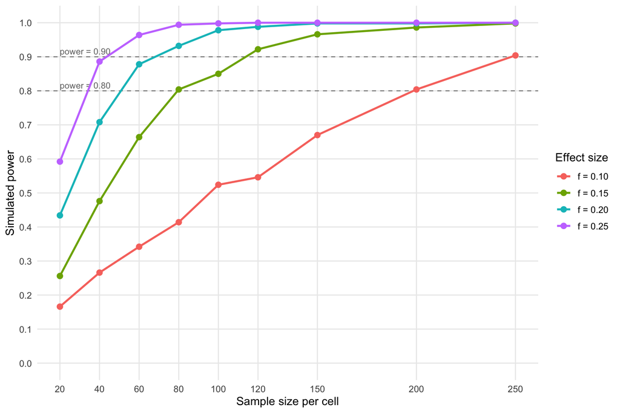

Simulated power curves for the 2 × 2 interaction. Dashed lines mark power = 0.80 and 0.90.

```r
sim_grid$f_label <- paste0("f = ", format(sim_grid$f, nsmall = 2))

plot_power <- ggplot(sim_grid,
                     aes(x = n_per_cell, y = power,
                         color = f_label, group = f_label)) +
  geom_hline(yintercept = c(0.80, 0.90),
             linetype = "dashed", color = "grey55") +
  annotate("text", x = min(sim_grid$n_per_cell), y = 0.80,
           label = "power = 0.80", vjust = -0.4, hjust = 0,
           size = 3.2, color = "grey45") +
  annotate("text", x = min(sim_grid$n_per_cell), y = 0.90,
           label = "power = 0.90", vjust = -0.4, hjust = 0,
           size = 3.2, color = "grey45") +
  geom_line(size = 1) +
  geom_point(size = 2.5) +
  scale_y_continuous(limits = c(0, 1), breaks = seq(0, 1, 0.1)) +
  scale_x_continuous(breaks = unique(sim_grid$n_per_cell)) +
  labs(
    x     = "Sample size per cell",
    y     = "Simulated power",
    color = "Effect size"
  ) +
  theme_minimal(base_size = 12) +
  theme(legend.position = "right",
        panel.grid.minor = element_blank())

plot_power
```

```r
ggsave(file.path(DESIGN_DIR, "power_curves.png"),
       plot = plot_power, width = 9, height = 6, dpi = 150)
```

## Alternative anchor: Chen & Li (2009)

Because our previous pilot is a bit different in terms of identity and exclusion, I also anchor on Chen & Li (2009, *AER*, 99: 431–457). This is the canonical Klee/Kandinsky paper — our current design implements their paradigm directly — so their identity effects are a natural reference for the *identity* leg of the new design.

### What Chen & Li reported

- **Other-other allocation task.** Ingroup vs outgroup allocation difference (normalised by endowment) is **32.2 %–38.4 %** across their five rounds, all significant at the 1 % level (Section II results; N = 566 subjects total).
- **Identity parameter for charity.** `a = 0.467` — participants weight another player’s payoff 47 % more heavily when that other player is an ingroup match (Table 2 MLE; N = 1896 observations from 432 treatment subjects).
- **Identity parameter for envy.** `b = -0.931` — envy toward ingroup matches is 93 % lower than toward outgroup matches.
- **Dictator-game choices** (Appendix A, Dict 1–5). Player A ingroup vs outgroup choice proportions differ by ~0.12; Player B by ~0.15.

### Translating those to Cohen’s f

Two reasonable readings:

- **Behavioural proportion differences.** Cohen’s *h* ≈ 0.24–0.32 → Cohen’s *f* ≈ **0.12–0.16** for the identity main effect.
- **Utility-parameter interpretation.** The 47 % charity increase with a ~35 % mean allocation gap → Cohen’s *f* ≈ **0.20–0.30**.

One caveat to flag in the preregistration: Chen & Li’s numbers describe their *identity main effect*, not an interaction with a second factor. The interaction in the new design could plausibly be smaller, equal, or larger depending on whether identity amplifies the exclusion mechanism. The four scenarios below span the plausible range.

### Sample sizes under this anchor

```r
chen_li_scenarios <- data.frame(
  scenario = c("Chen & Li (behavioural, low)",
               "Chen & Li (behavioural, mid)",
               "Chen & Li (utility param, mid)",
               "Chen & Li (utility param, high)"),
  f        = c(0.13, 0.16, 0.20, 0.25)
)

chen_li_results <- do.call(rbind, lapply(seq_len(nrow(chen_li_scenarios)), function(i) {
  cbind(scenario = chen_li_scenarios$scenario[i],
        power_2x2_interaction(chen_li_scenarios$f[i], alpha, power))
}))
chen_li_results$N_recruit <- ceiling(chen_li_results$N_total / (1 - 0.20))

knitr::kable(
  chen_li_results,
  caption = "Sample sizes under the Chen & Li (2009) anchor (α = 0.05, power = 0.90, 20 % attrition buffer)")
```

Sample sizes under the Chen & Li (2009) anchor (α = 0.05, power = 0.90, 20 % attrition buffer)

| scenario | f | f_squared | v_denom_df | N_total | n_per_cell | N_recruit |
| --- | --- | --- | --- | --- | --- | --- |
| Chen & Li (behavioural, low) | 0.13 | 0.0169 | 622 | 626 | 157 | 783 |
| Chen & Li (behavioural, mid) | 0.16 | 0.0256 | 411 | 415 | 104 | 519 |
| Chen & Li (utility param, mid) | 0.20 | 0.0400 | 263 | 267 | 67 | 334 |
| Chen & Li (utility param, high) | 0.25 | 0.0625 | 169 | 173 | 44 | 217 |

### Side-by-side comparison

```r
# primary_results doesn't have N_recruit yet (that column gets added below);
# add it here so both frames match before we rbind.
primary_with_buffer <- primary_results
primary_with_buffer$N_recruit <- ceiling(primary_with_buffer$N_total / (1 - 0.20))

cols_for_comparison <- c("scenario", "f", "N_total", "n_per_cell", "N_recruit")
comparison <- rbind(
  cbind(source = "Pilot anchor",     primary_with_buffer[, cols_for_comparison]),
  cbind(source = "Chen & Li anchor", chen_li_results[,      cols_for_comparison])
)
knitr::kable(comparison,
             caption = "Comparison of pilot-anchored and Chen & Li-anchored sample sizes")
```

Comparison of pilot-anchored and Chen & Li-anchored sample sizes

| source | scenario | f | N_total | n_per_cell | N_recruit |
| --- | --- | --- | --- | --- | --- |
| Pilot anchor | Pilot-derived (single-factor) | 0.106 | 940 | 235 | 1175 |
| Pilot anchor | Small (Cohen benchmark) | 0.100 | 1055 | 264 | 1319 |
| Pilot anchor | Small-to-medium | 0.150 | 471 | 118 | 589 |
| Pilot anchor | Medium (Cohen benchmark) | 0.250 | 173 | 44 | 217 |
| Chen & Li anchor | Chen & Li (behavioural, low) | 0.130 | 626 | 157 | 783 |
| Chen & Li anchor | Chen & Li (behavioural, mid) | 0.160 | 415 | 104 | 519 |
| Chen & Li anchor | Chen & Li (utility param, mid) | 0.200 | 267 | 67 | 334 |
| Chen & Li anchor | Chen & Li (utility param, high) | 0.250 | 173 | 44 | 217 |

## Recommendation

Chen & Li’s identity effects are larger. Depending on the reading, Cohen’s *f* falls in the **0.15–0.25** range. Taking those as the anchor for the interaction gives **475–600 total** at `f = 0.15`, and **~175–220 total** at `f = 0.25`.

The between-subjects interaction is the binding constraint. The within-subjects paired contrasts (in-group vs out-group in Round 2, easy vs hard recipient in Round 3) will be well-powered as a by-product.

## Attrition / exclusion buffer

Online samples typically lose 10–30 % to attention checks, dropouts, and comprehension failures. The table below applies a **30 %** buffer to the pilot-anchored primary results.

```r
buffer_rate <- 0.30
primary_results$N_recruit <- ceiling(primary_results$N_total / (1 - buffer_rate))
knitr::kable(
  primary_results[, c("scenario", "f", "N_total", "N_recruit")],
  caption = sprintf("Total N with a %d %% attrition buffer applied",
                    round(100 * buffer_rate)))
```

Total N with a 30 % attrition buffer applied

| scenario | f | N_total | N_recruit |
| --- | --- | --- | --- |
| Pilot-derived (single-factor) | 0.106 | 940 | 1343 |
| Small (Cohen benchmark) | 0.100 | 1055 | 1508 |
| Small-to-medium | 0.150 | 471 | 673 |
| Medium (Cohen benchmark) | 0.250 | 173 | 248 |